# Zotero group IAS

Published

18 November 2026

Zotero data of 17 November 2026 · IPBES Literature Report 0.7.0 · [source code on GitHub](https://github.com/IPBES-Data/IPBES.LiteratureReport)

This report shows the state of the Zotero group **IAS** ([open the group in Zotero](https://www.zotero.org/groups/2352922)). It gives an overview of the literature in the group, and lists the items which should be corrected.

Each item in the lists can be opened in the Zotero **web** library or in the Zotero **app** on your computer, so that it can be corrected directly. Corrected items disappear from the lists the next time the report is updated. Some checks compare the items with [OpenAlex](https://openalex.org), an open catalogue of scholarly publications.

## Summary

[output not shown]

**Please fix**: these items contain errors. **Please check**: these items may need a correction. **For information**: no action needed unless the group uses this, e.g. tags.

## Items to fix

The lists are sorted by importance. Use the search field above a list to find an item. **web** opens the item in the Zotero web library, **app** in the Zotero app.

### Retracted publications

These publications have been retracted. Check whether they should still be cited, and mark or remove them in Zotero.

| Open in Zotero | Title | DOI |
| --- | --- | --- |
| <a href="https://www.zotero.org/groups/2352922/items/LABYQWTN" target="_blank">web</a> &middot; <a href="zotero://select/groups/2352922/items/LABYQWTN">app</a> | RETRACTED ARTICLE: Origin and cross-species transmission of bat coronaviruses in China | <a href="https://doi.org/10.1038/s41467-020-17687-3" target="_blank">10.1038/s41467-020-17687-3</a> |

### DOI points to a different publication

The DOI of these items leads to a publication with a different title or year. Usually the DOI is wrong: open the DOI to see where it leads, and correct it in Zotero. If the titles match and only the year differs, the DOI is probably right and the date in Zotero wrong (unless it is a reprint or another edition): correct the date instead. Differences of one year (e.g. published online before print) are not listed.

If the DOI is right although title or year differ (e.g. a book chapter with the DOI of the whole book, or a wrong year in OpenAlex), add the line `DOI checked: correct` to Extra: the item is then no longer listed (the Zotero plugin offers this as “Keep as it is”).

Not listed here: items whose titles differ only by a subtitle missing on one side (OpenAlex often has the title without the part after the colon). They are most likely right; the Zotero plugin lists them separately.

| Open in Zotero | Title in Zotero | Year in Zotero | The DOI leads to | Its year | DOI |
| --- | --- | --- | --- | --- | --- |
| <a href="https://www.zotero.org/groups/2352922/items/ZXNT6I5E" target="_blank">web</a> &middot; <a href="zotero://select/groups/2352922/items/ZXNT6I5E">app</a> | Hunting and gathering as ways of perceiving the environment | 2000 | Hunting and gathering as ways of perceiving the environment | 2002 | <a href="https://doi.org/10.4324/9780203466025-10" target="_blank">10.4324/9780203466025-10</a> |
| <a href="https://www.zotero.org/groups/2352922/items/FB5JFWUZ" target="_blank">web</a> &middot; <a href="zotero://select/groups/2352922/items/FB5JFWUZ">app</a> | Exotic insects and their pathways for invasion | 2003 | Exotic Insects and Their Pathways for Invasion | 2013 | <a href="https://doi.org/10.2307/jj.41379851.6" target="_blank">10.2307/jj.41379851.6</a> |
| <a href="https://www.zotero.org/groups/2352922/items/85PNTEE7" target="_blank">web</a> &middot; <a href="zotero://select/groups/2352922/items/85PNTEE7">app</a> | Implementing invasive species management in an adaptive management framework | 2011 | Implementing invasive species management in an adaptive management framework | 1970 | <a href="https://doi.org/10.4102/koedoe.v53i2.1006" target="_blank">10.4102/koedoe.v53i2.1006</a> |
| <a href="https://www.zotero.org/groups/2352922/items/JWEZZF7K" target="_blank">web</a> &middot; <a href="zotero://select/groups/2352922/items/JWEZZF7K">app</a> | Catalogue of alien plants of the Czech Republic | 2002 | Catalogue of alien plants of the Czech Republic (3rd edition): species richness, status, distributions, habitats, regional invasion levels, introduction pathways and impacts | 2022 | <a href="https://doi.org/10.23855/preslia.2022.447" target="_blank">10.23855/preslia.2022.447</a> |
| <a href="https://www.zotero.org/groups/2352922/items/8V95WAH9" target="_blank">web</a> &middot; <a href="zotero://select/groups/2352922/items/8V95WAH9">app</a> | Sea level rise and implications for low lying islands, coasts and communities | 2019 | Sea Level Rise and Implications for Low-Lying Islands, Coasts and Communities | 2022 | <a href="https://doi.org/10.1017/9781009157964.006" target="_blank">10.1017/9781009157964.006</a> |
| <a href="https://www.zotero.org/groups/2352922/items/CTTVM7K6" target="_blank">web</a> &middot; <a href="zotero://select/groups/2352922/items/CTTVM7K6">app</a> | Invasive Alien Species: A New Synthesis | 2005 | Invasive Alien Species: The Nature of the Problem | 2013 | <a href="https://doi.org/10.2307/jj.41379768.6" target="_blank">10.2307/jj.41379768.6</a> |
| <a href="https://www.zotero.org/groups/2352922/items/IF8PR2XE" target="_blank">web</a> &middot; <a href="zotero://select/groups/2352922/items/IF8PR2XE">app</a> | The Anthropocene | 2000 | The “Anthropocene” | 2006 | <a href="https://doi.org/10.1007/3-540-26590-2_3" target="_blank">10.1007/3-540-26590-2_3</a> |
| <a href="https://www.zotero.org/groups/2352922/items/M7D5Y64U" target="_blank">web</a> &middot; <a href="zotero://select/groups/2352922/items/M7D5Y64U">app</a> | Climate Change 2014: Impacts, Adaptation, and Vulnerability. Part A: Global and Sectoral Aspects. | 2014 | Climate Change 2014 Impacts, Adaptation, and Vulnerability: Working Group II Contribution to the Fifth Assessment Report of the Intergovernmental Panel on Climate Change | 2014 | <a href="https://doi.org/10.1017/cbo9781107415379" target="_blank">10.1017/cbo9781107415379</a> |
| <a href="https://www.zotero.org/groups/2352922/items/N4YYI5KY" target="_blank">web</a> &middot; <a href="zotero://select/groups/2352922/items/N4YYI5KY">app</a> | Uneasy Relationships Between Ecology, History, and Restoration | 2010 | Restoration and History | 2010 | <a href="https://doi.org/10.4324/9780203860373" target="_blank">10.4324/9780203860373</a> |
| <a href="https://www.zotero.org/groups/2352922/items/PILBW3JL" target="_blank">web</a> &middot; <a href="zotero://select/groups/2352922/items/PILBW3JL">app</a> | Biosecurity, invasive species and the law. | 2018 | Routledge Handbook of Biodiversity and the Law | 2017 | <a href="https://doi.org/10.4324/9781315530857" target="_blank">10.4324/9781315530857</a> |

[output cut: 8 more lines]

### Items which are in the group more than once

These items are in the group more than once, with the same DOI, or with the same title, year and first author. Keep one copy and merge or delete the others, e.g. with *Duplicate Items* in the Zotero app.

| Open in Zotero | Title | Copies |
| --- | --- | --- |
| <a href="https://www.zotero.org/groups/2352922/items/EJ392XZV" target="_blank">web</a> &middot; <a href="zotero://select/groups/2352922/items/EJ392XZV">app</a><br><a href="https://www.zotero.org/group… | Invasive alien plants in protected areas: threats, opportunities, and the way forward | 3 |
| <a href="https://www.zotero.org/groups/2352922/items/SII6AX76" target="_blank">web</a> &middot; <a href="zotero://select/groups/2352922/items/SII6AX76">app</a><br><a href="https://www.zotero.org/group… | Eichhornia crassipes Mart. (Solms-Laubach) (water hyacinth) | 2 |
| <a href="https://www.zotero.org/groups/2352922/items/BW28LAD5" target="_blank">web</a> &middot; <a href="zotero://select/groups/2352922/items/BW28LAD5">app</a><br><a href="https://www.zotero.org/group… | Invasive alien mammals of European Union concern | 2 |
| <a href="https://www.zotero.org/groups/2352922/items/K5U3QNCX" target="_blank">web</a> &middot; <a href="zotero://select/groups/2352922/items/K5U3QNCX">app</a><br><a href="https://www.zotero.org/group… | Invasive species removals and scale – contrasting island and mainland experience | 2 |
| <a href="https://www.zotero.org/groups/2352922/items/XKKAU2IV" target="_blank">web</a> &middot; <a href="zotero://select/groups/2352922/items/XKKAU2IV">app</a><br><a href="https://www.zotero.org/group… | Chapter Six - A Vision for Global Biodiversity Monitoring With Citizen Science | 2 |
| <a href="https://www.zotero.org/groups/2352922/items/5C83V3J8" target="_blank">web</a> &middot; <a href="zotero://select/groups/2352922/items/5C83V3J8">app</a><br><a href="https://www.zotero.org/group… | Plant Invasions and the Role of Riparian Habitats: A Comparison of Four Species Alien to Central Europe | 2 |
| <a href="https://www.zotero.org/groups/2352922/items/KJIAQIGQ" target="_blank">web</a> &middot; <a href="zotero://select/groups/2352922/items/KJIAQIGQ">app</a><br><a href="https://www.zotero.org/group… | Plant Invasions in Protected Areas: Patterns, Problems and Challenges | 2 |

### DOI field with an invalid DOI

The DOI field of these items contains something which is not a valid DOI. Correct or remove it.

| Open in Zotero | Title | Content of the DOI field |
| --- | --- | --- |
| <a href="https://www.zotero.org/groups/2352922/items/GNG7XTF6" target="_blank">web</a> &middot; <a href="zotero://select/groups/2352922/items/GNG7XTF6">app</a> | Novel ecosystems: implications for conservation and restoration | https://www.sciencedirect.com/science/article/abs/pii/S0169534709002018 |
| <a href="https://www.zotero.org/groups/2352922/items/ABXB2YE3" target="_blank">web</a> &middot; <a href="zotero://select/groups/2352922/items/ABXB2YE3">app</a> | Plastic pollution in the world's oceans: more than 5 trillion plastic pieces weighing over 250,000 tons afloat at sea | 10.1371/ journal.pone.0111913 |
| <a href="https://www.zotero.org/groups/2352922/items/FYJYPZ7I" target="_blank">web</a> &middot; <a href="zotero://select/groups/2352922/items/FYJYPZ7I">app</a> | Biological Invasions by Exotic Grasses, the Grass/Fire Cycle, and Global Change | annurev.es.23.110192.000431 |

### DOI which does not exist

The DOI of these items does not exist at doi.org: usually a typo, a shortened DOI, or a DOI with extra characters at the end. Where the DOI without these characters exists, it is given as suggestion. Otherwise find the right DOI, or remove it (then the search by title in OpenAlex can offer one).

| Open in Zotero | Title | Content of the DOI field | Suggestion |
| --- | --- | --- | --- |
| <a href="https://www.zotero.org/groups/2352922/items/CDCWFURX" target="_blank">web</a> &middot; <a href="zotero://select/groups/2352922/items/CDCWFURX">app</a> | Landscapes of the Anthropocene: from dominion to dependence? | 10.4324/9781315879642-7 |  |
| <a href="https://www.zotero.org/groups/2352922/items/2ELAFJ42" target="_blank">web</a> &middot; <a href="zotero://select/groups/2352922/items/2ELAFJ42">app</a> | Contested narratives of pastoral vulnerability and risk in Ethiopia’s Afar region | 10.3362/2041-7136.2010.014 |  |
| <a href="https://www.zotero.org/groups/2352922/items/7UZIC5WJ" target="_blank">web</a> &middot; <a href="zotero://select/groups/2352922/items/7UZIC5WJ">app</a> | Rhopilema nomadica: A lessepsian scyphomedusan new to the Mediterranean coast of Turkey | 10.1080/00212210.1995.10688827 |  |
| <a href="https://www.zotero.org/groups/2352922/items/3MLHJ4IF" target="_blank">web</a> &middot; <a href="zotero://select/groups/2352922/items/3MLHJ4IF">app</a> | Law is order, and good law is good order: The role of governance in the regulation of invasive alien species | 10.3316/agispt.20121130 |  |
| <a href="https://www.zotero.org/groups/2352922/items/I2ZHTDFJ" target="_blank">web</a> &middot; <a href="zotero://select/groups/2352922/items/I2ZHTDFJ">app</a> | Consumer-Resource Dynamics (MPB-36) | 10.1515/9781400847259/html |  |
| <a href="https://www.zotero.org/groups/2352922/items/YPDWJYJB" target="_blank">web</a> &middot; <a href="zotero://select/groups/2352922/items/YPDWJYJB">app</a> | Invasive alien plants in South Africa: how well do we understand the ecological impacts?: working for water | 10.10520/ejc96214 |  |
| <a href="https://www.zotero.org/groups/2352922/items/K8WBS93R" target="_blank">web</a> &middot; <a href="zotero://select/groups/2352922/items/K8WBS93R">app</a> | 100 years of biological control of invasive alien plants in South Africa : history, practice and achievements : news & views | 10.10520/ejc142072 |  |
| <a href="https://www.zotero.org/groups/2352922/items/S27ECEYA" target="_blank">web</a> &middot; <a href="zotero://select/groups/2352922/items/S27ECEYA">app</a> | Survey of the status and management of sympatric bushbuck and nyala in KwaZulu-Natal, South Africa : research article | 10.10520/ejc117215 |  |
| <a href="https://www.zotero.org/groups/2352922/items/PYQQCD7L" target="_blank">web</a> &middot; <a href="zotero://select/groups/2352922/items/PYQQCD7L">app</a> | Feral Mallards: a risk for hybridisation with wild Pacific Black Ducks in Australia? | 10.3316/informit.669302995398699 |  |
| <a href="https://www.zotero.org/groups/2352922/items/TZMIRG9R" target="_blank">web</a> &middot; <a href="zotero://select/groups/2352922/items/TZMIRG9R">app</a> | Scenario tree risk analysis of zero detections and the eradication of yellow crazy ant (’<i>Anoplolepis gracilipes</i>’ (Smith)), in New South Wales, Australia | 10.3316/informit.593474062968814 |  |

[output cut: 1 more lines]

### DOI field with a link or prefix instead of the DOI

The DOI field of these items contains the DOI as a link (`https://doi.org/…`) or with a prefix (`DOI …`). Citation styles add the link themselves, so it would appear twice. Replace it with the DOI only.

**✔ Nothing to fix.**

### ISSN not in the standard form

The ISSN field of these items is not in the standard form `1234-567X` (several separated by “,”), or contains something which is not a valid ISSN, e.g. an ISBN.

| Open in Zotero | Title | Content of the ISSN field | Standard form | Not a valid ISSN |
| --- | --- | --- | --- | --- |
| <a href="https://www.zotero.org/groups/2352922/items/CPYHHZHB" target="_blank">web</a> &middot; <a href="zotero://select/groups/2352922/items/CPYHHZHB">app</a> | Culture at the centre of community based aged care in a remote Australian Indigenous setting: a case study of the development of Yuendumu Old People's Programme | 1445 - 6354 | NA | 1445, -, 6354 |
| <a href="https://www.zotero.org/groups/2352922/items/YMJD7FSN" target="_blank">web</a> &middot; <a href="zotero://select/groups/2352922/items/YMJD7FSN">app</a> | Changes and Degradation in a <i>Posidonia oceanica</i> Bed Invaded by the Introduced Tropical Alga <i>Caulerpa taxifolia</i> in the North Western Mediterranean | 2009-11-23 | NA | 2009-11-23 |
| <a href="https://www.zotero.org/groups/2352922/items/6W3IH3J6" target="_blank">web</a> &middot; <a href="zotero://select/groups/2352922/items/6W3IH3J6">app</a> | Alterations of the structure of <i>Posidonia oceanica</i> beds due to the introduced alga <i>Caulerpa taxifolia</i> | 214-8358 | NA | 214-8358 |
| <a href="https://www.zotero.org/groups/2352922/items/AWFNDA3B" target="_blank">web</a> &middot; <a href="zotero://select/groups/2352922/items/AWFNDA3B">app</a> | Biotic resistance in marine environments | https://onlinelibrary.wiley.com/doi/epdf/10.1111/ele.12106 | NA | https://onlinelibrary.wiley.com/doi/epdf/10.1111/ele.12106 |
| <a href="https://www.zotero.org/groups/2352922/items/Y2LWTJNI" target="_blank">web</a> &middot; <a href="zotero://select/groups/2352922/items/Y2LWTJNI">app</a> | Automated Counting of the Northern Pacific Sea Star in the Derwent Using Shape Recognition | null | NA | null |
| <a href="https://www.zotero.org/groups/2352922/items/35WUEQ3G" target="_blank">web</a> &middot; <a href="zotero://select/groups/2352922/items/35WUEQ3G">app</a> | Robotic detection and tracking of Crown-of-Thorns starfish | null | NA | null |
| <a href="https://www.zotero.org/groups/2352922/items/3T95E4SW" target="_blank">web</a> &middot; <a href="zotero://select/groups/2352922/items/3T95E4SW">app</a> | The Traditional Ecological Knowledge of Soliga Tribe on Eradication of <i>Lantana camara</i> and their Livelihood | 1973 – 2880 | NA | 1973, –, 2880 |
| <a href="https://www.zotero.org/groups/2352922/items/MB3HZMWT" target="_blank">web</a> &middot; <a href="zotero://select/groups/2352922/items/MB3HZMWT">app</a> | Rapid bioinvasion of alien mussel <i>Mytella strigata</i> (Hanley, 1843) (Bivalvia: Mytilidae) along Kerala coast, India: Will this impact the livelihood of fishers in Ashtamudi Lake? | 2321–340X | NA | 2321–340X |
| <a href="https://www.zotero.org/groups/2352922/items/394PKF6V" target="_blank">web</a> &middot; <a href="zotero://select/groups/2352922/items/394PKF6V">app</a> | Biodiversity: The ravages of guns, nets and bulldozers | 9788578110796 | NA | 9788578110796 |
| <a href="https://www.zotero.org/groups/2352922/items/IWZV8J6F" target="_blank">web</a> &middot; <a href="zotero://select/groups/2352922/items/IWZV8J6F">app</a> | Water hyacinth in Africa and the Middle East: A survey of problems and solutions | 0-88936-933-X | NA | 0-88936-933-X |

[output cut: 10 more lines]

### DOI in the wrong field

These items have no DOI in the DOI field, but a DOI in the URL or Extra field. Copy the DOI into the DOI field.

| Open in Zotero | Title | DOI in URL | DOI in Extra |
| --- | --- | --- | --- |
| <a href="https://www.zotero.org/groups/2352922/items/8DTZDVEX" target="_blank">web</a> &middot; <a href="zotero://select/groups/2352922/items/8DTZDVEX">app</a> | First report of marine alien species in mainland Ecuador: threats of invasion in rocky shores. | <a href="https://doi.org/10.2305/iucn.ch.2019.ssc-op.62.en" target="_blank">10.2305/iucn.ch.2019.ssc-op.62.en</a> |  |
| <a href="https://www.zotero.org/groups/2352922/items/Q7Z9NG4Y" target="_blank">web</a> &middot; <a href="zotero://select/groups/2352922/items/Q7Z9NG4Y">app</a> | Biogeography | <a href="https://doi.org/10.1086/665420" target="_blank">10.1086/665420</a> |  |
| <a href="https://www.zotero.org/groups/2352922/items/BRAXLYDW" target="_blank">web</a> &middot; <a href="zotero://select/groups/2352922/items/BRAXLYDW">app</a> | The naturalised flora of Micronesia and World War II. | <a href="https://doi.org/10.5962/bhl.title.16386" target="_blank">10.5962/bhl.title.16386</a> |  |
| <a href="https://www.zotero.org/groups/2352922/items/MCAXFX3N" target="_blank">web</a> &middot; <a href="zotero://select/groups/2352922/items/MCAXFX3N">app</a> | Many tongues, one people: The making of Tharu identity in Nepal | <a href="https://doi.org/10.7591/j.ctv3s8mfn" target="_blank">10.7591/j.ctv3s8mfn</a> |  |
| <a href="https://www.zotero.org/groups/2352922/items/L7QTT5ID" target="_blank">web</a> &middot; <a href="zotero://select/groups/2352922/items/L7QTT5ID">app</a> | Containment as a strategic option for managing plant invasion | <a href="https://doi.org/10.3316/ielapa.685341871862730" target="_blank">10.3316/ielapa.685341871862730</a> |  |
| <a href="https://www.zotero.org/groups/2352922/items/GJ8EZP9D" target="_blank">web</a> &middot; <a href="zotero://select/groups/2352922/items/GJ8EZP9D">app</a> | 5 Mediation between Indigenous and Non-Indigenous Knowledge Systems: Another Analysis of “Two-Way” Conservation in Northern Australia | <a href="https://doi.org/10.3138/9781487513764-006/html" target="_blank">10.3138/9781487513764-006/html</a> |  |
| <a href="https://www.zotero.org/groups/2352922/items/RJLEHPRT" target="_blank">web</a> &middot; <a href="zotero://select/groups/2352922/items/RJLEHPRT">app</a> | Emerald ash borer, black ash, and Native american basketmaking | <a href="https://doi.org/10.4324/9781315268774-11/emerald-ash-borer-black-ash-native-american-basketmaking-therese-poland-marla-emery-tina-ciaramitaro-ed-pigeon-angie-pigeon" target="_blank">10.4324/9… |  |
| <a href="https://www.zotero.org/groups/2352922/items/CPYHHZHB" target="_blank">web</a> &middot; <a href="zotero://select/groups/2352922/items/CPYHHZHB">app</a> | Culture at the centre of community based aged care in a remote Australian Indigenous setting: a case study of the development of Yuendumu Old People's Programme | <a href="https://doi.org/10.3316/informit.396807774541079" target="_blank">10.3316/informit.396807774541079</a> |  |
| <a href="https://www.zotero.org/groups/2352922/items/L3STKXRM" target="_blank">web</a> &middot; <a href="zotero://select/groups/2352922/items/L3STKXRM">app</a> | Reptiles and amphibians of the Pacific Islands: a comprehensive guide | <a href="https://doi.org/10.1525/j.ctt2jcc1n" target="_blank">10.1525/j.ctt2jcc1n</a> |  |
| <a href="https://www.zotero.org/groups/2352922/items/WUTPCJ6T" target="_blank">web</a> &middot; <a href="zotero://select/groups/2352922/items/WUTPCJ6T">app</a> | People and Woods in Scotland: A History | <a href="https://doi.org/10.3366/j.ctvxcrr4m" target="_blank">10.3366/j.ctvxcrr4m</a> |  |

[output cut: 2 more lines]

### DOI not found in OpenAlex

These DOIs exist, but were not found in OpenAlex (DOIs which do not exist are listed above). If the DOI leads to the right publication, the publication is simply not (yet) in OpenAlex and nothing needs to be done.

| Open in Zotero | Title | DOI |
| --- | --- | --- |
| <a href="https://www.zotero.org/groups/2352922/items/HQTI4ZNS" target="_blank">web</a> &middot; <a href="zotero://select/groups/2352922/items/HQTI4ZNS">app</a> | The IPBES regional assessment report on biodiversity and ecosystem services for Africa | <a href="https://doi.org/10.5281/zenodo.3236066" target="_blank">10.5281/zenodo.3236066</a> |
| <a href="https://www.zotero.org/groups/2352922/items/7C76MTQP" target="_blank">web</a> &middot; <a href="zotero://select/groups/2352922/items/7C76MTQP">app</a> | Algae | <a href="https://doi.org/10.1525/9780520948433-008" target="_blank">10.1525/9780520948433-008</a> |
| <a href="https://www.zotero.org/groups/2352922/items/T3BX4AC3" target="_blank">web</a> &middot; <a href="zotero://select/groups/2352922/items/T3BX4AC3">app</a> | Effects of the invasive seagrass <i>Halophila stipulacea</i> on the native seagrass <i>Cymodocea nodosa</i> | <a href="https://doi.org/10.13140/2.1.3086.6888" target="_blank">10.13140/2.1.3086.6888</a> |
| <a href="https://www.zotero.org/groups/2352922/items/R64DPA3Y" target="_blank">web</a> &middot; <a href="zotero://select/groups/2352922/items/R64DPA3Y">app</a> | Developing pragmatic maps of establishment likelihood for plant pests | <a href="https://doi.org/10.13140/rg.2.2.21964.23685" target="_blank">10.13140/rg.2.2.21964.23685</a> |
| <a href="https://www.zotero.org/groups/2352922/items/KXWBBEES" target="_blank">web</a> &middot; <a href="zotero://select/groups/2352922/items/KXWBBEES">app</a> | Control of freshwater invasive species: Global evidence for the effects of selected interventions | <a href="https://doi.org/10.13140/rg.2.2.22197.58084" target="_blank">10.13140/rg.2.2.22197.58084</a> |
| <a href="https://www.zotero.org/groups/2352922/items/NHGKZKH2" target="_blank">web</a> &middot; <a href="zotero://select/groups/2352922/items/NHGKZKH2">app</a> | Risk Assessment for Controlling Mosquito Vectors with Engineered Nucleases: Contained field release for Sterile Male Construct Risk assessment final report | <a href="https://doi.org/10.25919/v424-4k80" target="_blank">10.25919/v424-4k80</a> |
| <a href="https://www.zotero.org/groups/2352922/items/2RQ6CLTS" target="_blank">web</a> &middot; <a href="zotero://select/groups/2352922/items/2RQ6CLTS">app</a> | Towards an early warning and information system for invasive alien species (IAS) threatening biodiversity in Europe | <a href="https://doi.org/10.2800/4167" target="_blank">10.2800/4167</a> |
| <a href="https://www.zotero.org/groups/2352922/items/SEY8PFQ5" target="_blank">web</a> &middot; <a href="zotero://select/groups/2352922/items/SEY8PFQ5">app</a> | Reforming the WTO – Towards a sustainable and effective multilateral trading system | <a href="https://doi.org/10.2781/272480" target="_blank">10.2781/272480</a> |
| <a href="https://www.zotero.org/groups/2352922/items/MIBPMHP5" target="_blank">web</a> &middot; <a href="zotero://select/groups/2352922/items/MIBPMHP5">app</a> | The methodological assessment report on scenarios and models of biodiversity and ecosystem services | <a href="https://doi.org/10.5281/zenodo.3235428" target="_blank">10.5281/zenodo.3235428</a> |
| <a href="https://www.zotero.org/groups/2352922/items/DEHK6HQZ" target="_blank">web</a> &middot; <a href="zotero://select/groups/2352922/items/DEHK6HQZ">app</a> | Assessing biodiversity in Europe : the 2010 report | <a href="https://doi.org/10.2800/42824" target="_blank">10.2800/42824</a> |

[output cut: 40 more lines]

### Missing or unusual publication year

These items have no date, a date from which no year could be read, or a year in the future. Correct the date in Zotero.

| Open in Zotero | Title | Date | Problem | Date in OpenAlex |
| --- | --- | --- | --- | --- |
| <a href="https://www.zotero.org/groups/2352922/items/GCTC6FC8" target="_blank">web</a> &middot; <a href="zotero://select/groups/2352922/items/GCTC6FC8">app</a> |  |  | No date | NA |
| <a href="https://www.zotero.org/groups/2352922/items/Q4DE2EIG" target="_blank">web</a> &middot; <a href="zotero://select/groups/2352922/items/Q4DE2EIG">app</a> |  |  | No date | NA |
| <a href="https://www.zotero.org/groups/2352922/items/U4UHDZBF" target="_blank">web</a> &middot; <a href="zotero://select/groups/2352922/items/U4UHDZBF">app</a> |  |  | No date | NA |
| <a href="https://www.zotero.org/groups/2352922/items/97T963K9" target="_blank">web</a> &middot; <a href="zotero://select/groups/2352922/items/97T963K9">app</a> |  |  | No date | NA |
| <a href="https://www.zotero.org/groups/2352922/items/QQE25IXG" target="_blank">web</a> &middot; <a href="zotero://select/groups/2352922/items/QQE25IXG">app</a> |  |  | No date | NA |
| <a href="https://www.zotero.org/groups/2352922/items/I57UUYDE" target="_blank">web</a> &middot; <a href="zotero://select/groups/2352922/items/I57UUYDE">app</a> |  |  | No date | NA |
| <a href="https://www.zotero.org/groups/2352922/items/GUZI523J" target="_blank">web</a> &middot; <a href="zotero://select/groups/2352922/items/GUZI523J">app</a> |  |  | No date | NA |
| <a href="https://www.zotero.org/groups/2352922/items/GMTQ5IP4" target="_blank">web</a> &middot; <a href="zotero://select/groups/2352922/items/GMTQ5IP4">app</a> |  |  | No date | NA |
| <a href="https://www.zotero.org/groups/2352922/items/3RPXJPTF" target="_blank">web</a> &middot; <a href="zotero://select/groups/2352922/items/3RPXJPTF">app</a> |  |  | No date | NA |
| <a href="https://www.zotero.org/groups/2352922/items/VI6G8EQG" target="_blank">web</a> &middot; <a href="zotero://select/groups/2352922/items/VI6G8EQG">app</a> |  |  | No date | NA |

[output cut: 9 more lines]

### Empty journal, volume, issue or pages, found in OpenAlex

These journal articles have an empty journal, volume, issue or pages field, and OpenAlex has the value for their DOI. Check it with the DOI and fill in the field.

| Open in Zotero | Title | Field | Value in OpenAlex | DOI |
| --- | --- | --- | --- | --- |
| <a href="https://www.zotero.org/groups/2352922/items/EAY98IYC" target="_blank">web</a> &middot; <a href="zotero://select/groups/2352922/items/EAY98IYC">app</a> | Acceleration of the contribution of the Greenland and Antarctic ice sheets to sea level rise | Volume | 38 | <a href="https://doi.org/10.1029/2011gl046583" target="_blank">10.1029/2011gl046583</a> |
| <a href="https://www.zotero.org/groups/2352922/items/EAY98IYC" target="_blank">web</a> &middot; <a href="zotero://select/groups/2352922/items/EAY98IYC">app</a> | Acceleration of the contribution of the Greenland and Antarctic ice sheets to sea level rise | Issue | 5 | <a href="https://doi.org/10.1029/2011gl046583" target="_blank">10.1029/2011gl046583</a> |
| <a href="https://www.zotero.org/groups/2352922/items/EAY98IYC" target="_blank">web</a> &middot; <a href="zotero://select/groups/2352922/items/EAY98IYC">app</a> | Acceleration of the contribution of the Greenland and Antarctic ice sheets to sea level rise | Pages | n/a | <a href="https://doi.org/10.1029/2011gl046583" target="_blank">10.1029/2011gl046583</a> |
| <a href="https://www.zotero.org/groups/2352922/items/YMJD7FSN" target="_blank">web</a> &middot; <a href="zotero://select/groups/2352922/items/YMJD7FSN">app</a> | Changes and Degradation in a <i>Posidonia oceanica</i> Bed Invaded by the Introduced Tropical Alga <i>Caulerpa taxifolia</i> in the North Western Mediterranean | Issue | 1-6 | <a href="https://doi.org/10.1515/botm.1995.38.1-6.79" target="_blank">10.1515/botm.1995.38.1-6.79</a> |
| <a href="https://www.zotero.org/groups/2352922/items/9PKZ6CU4" target="_blank">web</a> &middot; <a href="zotero://select/groups/2352922/items/9PKZ6CU4">app</a> | Climate Change Impacts on Marine Ecosystems | Issue | 1 | <a href="https://doi.org/10.1146/annurev-marine-041911-111611" target="_blank">10.1146/annurev-marine-041911-111611</a> |
| <a href="https://www.zotero.org/groups/2352922/items/YEMLUSDJ" target="_blank">web</a> &middot; <a href="zotero://select/groups/2352922/items/YEMLUSDJ">app</a> | Electronic-nose devices - Potential for noninvasive early disease-detection applications | Issue | 1401 | <a href="https://doi.org/10.5281/zenodo.18179902" target="_blank">10.5281/zenodo.18179902</a> |
| <a href="https://www.zotero.org/groups/2352922/items/MNV4Z79Q" target="_blank">web</a> &middot; <a href="zotero://select/groups/2352922/items/MNV4Z79Q">app</a> | Hunters and Bureaucrats: Power, Knowledge and Aboriginal-State Relations in the Southwest Yukon | Journal | ARCTIC | <a href="https://doi.org/10.14430/arctic551" target="_blank">10.14430/arctic551</a> |
| <a href="https://www.zotero.org/groups/2352922/items/MNV4Z79Q" target="_blank">web</a> &middot; <a href="zotero://select/groups/2352922/items/MNV4Z79Q">app</a> | Hunters and Bureaucrats: Power, Knowledge and Aboriginal-State Relations in the Southwest Yukon | Volume | 57 | <a href="https://doi.org/10.14430/arctic551" target="_blank">10.14430/arctic551</a> |
| <a href="https://www.zotero.org/groups/2352922/items/MNV4Z79Q" target="_blank">web</a> &middot; <a href="zotero://select/groups/2352922/items/MNV4Z79Q">app</a> | Hunters and Bureaucrats: Power, Knowledge and Aboriginal-State Relations in the Southwest Yukon | Issue | 1 | <a href="https://doi.org/10.14430/arctic551" target="_blank">10.14430/arctic551</a> |
| <a href="https://www.zotero.org/groups/2352922/items/7AKKJ6K5" target="_blank">web</a> &middot; <a href="zotero://select/groups/2352922/items/7AKKJ6K5">app</a> | Island and taxon effects in parasitism and resistance of Lesser Antillean birds | Journal | Ecology | <a href="https://doi.org/10.1890/0012-9658(2000)081[1959:iateip]2.0.co;2" target="_blank">10.1890/0012-9658(2000)081[1959:iateip]2.0.co;2</a> |

[output cut: 6 more lines]

### Language not given as a language code

The language of these items is not given as a language code (`en`, `fr`, `en-US`), e.g. as `English` or `eng`. Citation styles only recognise the codes. Where the language was recognised, the code is shown; otherwise look up the code in the [ISO 639-1 list](https://en.wikipedia.org/wiki/List_of_ISO_639_language_codes).

| Open in Zotero | Title | Language | Language code |
| --- | --- | --- | --- |
| <a href="https://www.zotero.org/groups/2352922/items/E9ZSZ84E" target="_blank">web</a> &middot; <a href="zotero://select/groups/2352922/items/E9ZSZ84E">app</a> | State says goodbye to tree-killing pest | English (United States), en-US | NA |
| <a href="https://www.zotero.org/groups/2352922/items/FF5QVLTE" target="_blank">web</a> &middot; <a href="zotero://select/groups/2352922/items/FF5QVLTE">app</a> | Key attributes influence the performance of local weed management programs in the southwest United States | English (US) | NA |
| <a href="https://www.zotero.org/groups/2352922/items/4TYHBU7S" target="_blank">web</a> &middot; <a href="zotero://select/groups/2352922/items/4TYHBU7S">app</a> | Priorisation spatiale des actions de gestion des plantes exotiques envahissantes : une étape-clé de la conservation à long terme des milieux naturels à la Réunion. Version 1 | Français | NA |
| <a href="https://www.zotero.org/groups/2352922/items/GSKVUWX3" target="_blank">web</a> &middot; <a href="zotero://select/groups/2352922/items/GSKVUWX3">app</a> | An Inventory and Assessment of Invasive Alien Plant Species of Nepal | eng nep | NA |
| <a href="https://www.zotero.org/groups/2352922/items/KF7HRR85" target="_blank">web</a> &middot; <a href="zotero://select/groups/2352922/items/KF7HRR85">app</a> | Invasive Agroforestry trees: Problems and solutions | EN00420042000 | NA |

### Language differs from OpenAlex

The language of these items differs from the language of their DOI in OpenAlex. OpenAlex detects the language from the title and abstract, and many publications in other languages have an English abstract: the language in Zotero is often right. Check the publication and correct the language if needed; if it is right, add the line `Language checked: correct` to Extra, and the item is no longer listed.

| Open in Zotero | Title | Language | Language in OpenAlex | DOI |
| --- | --- | --- | --- | --- |
| <a href="https://www.zotero.org/groups/2352922/items/JKAZFB3F" target="_blank">web</a> &middot; <a href="zotero://select/groups/2352922/items/JKAZFB3F">app</a> | Defining the Impact of Non-Native Species: Impact of Non-Native Species | es | en | <a href="https://doi.org/10.1111/cobi.12299" target="_blank">10.1111/cobi.12299</a> |
| <a href="https://www.zotero.org/groups/2352922/items/RNVAT2QS" target="_blank">web</a> &middot; <a href="zotero://select/groups/2352922/items/RNVAT2QS">app</a> | Edge-effects Drive Tropical Forest Fragments Towards an Early-Successional System | en | pt | <a href="https://doi.org/10.1111/j.1744-7429.2008.00454.x" target="_blank">10.1111/j.1744-7429.2008.00454.x</a> |
| <a href="https://www.zotero.org/groups/2352922/items/FNAYIG8M" target="_blank">web</a> &middot; <a href="zotero://select/groups/2352922/items/FNAYIG8M">app</a> | Hydrological and ecological impacts of dams on the Kafue Flats floodplain system, southern Zambia | en | es | <a href="https://doi.org/10.1016/j.pce.2005.06.009" target="_blank">10.1016/j.pce.2005.06.009</a> |
| <a href="https://www.zotero.org/groups/2352922/items/MF5HGI35" target="_blank">web</a> &middot; <a href="zotero://select/groups/2352922/items/MF5HGI35">app</a> | Invasive crayfish and freshwater fishes of the world | en | fr | <a href="https://doi.org/10.20506/rst.29.2.1973" target="_blank">10.20506/rst.29.2.1973</a> |
| <a href="https://www.zotero.org/groups/2352922/items/LQEUFELW" target="_blank">web</a> &middot; <a href="zotero://select/groups/2352922/items/LQEUFELW">app</a> | The challenge of implementing the European network of protected areas Natura 2000 | es | en | <a href="https://doi.org/10.1111/cobi.12366" target="_blank">10.1111/cobi.12366</a> |
| <a href="https://www.zotero.org/groups/2352922/items/QAFDLX4B" target="_blank">web</a> &middot; <a href="zotero://select/groups/2352922/items/QAFDLX4B">app</a> | <i>Megalops atlanticus</i> (Megalopidae), un nuevo pez en el océano Pacífico; información sobre su importancia pesquera | en | es | <a href="https://doi.org/10.21897/rmvz.826" target="_blank">10.21897/rmvz.826</a> |
| <a href="https://www.zotero.org/groups/2352922/items/BHNSKPQS" target="_blank">web</a> &middot; <a href="zotero://select/groups/2352922/items/BHNSKPQS">app</a> | Pukkellaks i Norge 2021 | nb | no | <a href="https://doi.org/10.5281/zenodo.18178095" target="_blank">10.5281/zenodo.18178095</a> |
| <a href="https://www.zotero.org/groups/2352922/items/JB228MCY" target="_blank">web</a> &middot; <a href="zotero://select/groups/2352922/items/JB228MCY">app</a> | The invasive snowflake coral (<i>Carijoa riisei</i>) in the Tropical Eastern Pacific, Colombia | en | es | <a href="https://doi.org/10.15517/rbt.v62i0.16276" target="_blank">10.15517/rbt.v62i0.16276</a> |
| <a href="https://www.zotero.org/groups/2352922/items/YE58VVFC" target="_blank">web</a> &middot; <a href="zotero://select/groups/2352922/items/YE58VVFC">app</a> | Biosecurity, risk and policy: a New Zealand perspective | en | de | <a href="https://doi.org/10.1007/s00003-011-0673-8" target="_blank">10.1007/s00003-011-0673-8</a> |
| <a href="https://www.zotero.org/groups/2352922/items/QNV36SHA" target="_blank">web</a> &middot; <a href="zotero://select/groups/2352922/items/QNV36SHA">app</a> | Estado actual del conocimiento de las bioinvasiones marinas en Venezuela: temáticas desarrolladas y tendencia temporal | en | es | <a href="https://doi.org/10.4067/s0717-65382020000100001" target="_blank">10.4067/s0717-65382020000100001</a> |

### No language

These items have no language. Where possible, a language is proposed: from OpenAlex for items with a DOI, or else detected from the abstract (with the Compact Language Detector 2, a statistical method, not AI). Both are the language of the title or abstract, which may differ from the language of the publication.

| Open in Zotero | Title | Proposed language | From | DOI |
| --- | --- | --- | --- | --- |
| <a href="https://www.zotero.org/groups/2352922/items/HSGVXM7S" target="_blank">web</a> &middot; <a href="zotero://select/groups/2352922/items/HSGVXM7S">app</a> | Introduced marine plants, with special reference to macroalgae: mechanisms and impact. | en | OpenAlex | <a href="https://doi.org/10.5281/zenodo.18179366" target="_blank">10.5281/zenodo.18179366</a> |
| <a href="https://www.zotero.org/groups/2352922/items/CDCWFURX" target="_blank">web</a> &middot; <a href="zotero://select/groups/2352922/items/CDCWFURX">app</a> | Landscapes of the Anthropocene: from dominion to dependence? | NA | NA | <a href="https://doi.org/10.4324/9781315879642-7" target="_blank">10.4324/9781315879642-7</a> |
| <a href="https://www.zotero.org/groups/2352922/items/NMECR6KP" target="_blank">web</a> &middot; <a href="zotero://select/groups/2352922/items/NMECR6KP">app</a> | International Plant Protection Convention | en | OpenAlex | <a href="https://doi.org/10.1111/j.1365-3059.1952.tb00013.x" target="_blank">10.1111/j.1365-3059.1952.tb00013.x</a> |
| <a href="https://www.zotero.org/groups/2352922/items/S3C29BDK" target="_blank">web</a> &middot; <a href="zotero://select/groups/2352922/items/S3C29BDK">app</a> | Important Issues on Risk Assessment of Manufactured Nanomaterials | NA | NA |  |
| <a href="https://www.zotero.org/groups/2352922/items/WDQAEKZH" target="_blank">web</a> &middot; <a href="zotero://select/groups/2352922/items/WDQAEKZH">app</a> | In-water cleaning technologies: Review of information | en | OpenAlex | <a href="https://doi.org/10.5281/zenodo.18180137" target="_blank">10.5281/zenodo.18180137</a> |
| <a href="https://www.zotero.org/groups/2352922/items/TSMXQX6J" target="_blank">web</a> &middot; <a href="zotero://select/groups/2352922/items/TSMXQX6J">app</a> | Impact of seaweed farming on socio-economic development of a fishing community in Palk Bay, Southeast Coast of India | en | OpenAlex | <a href="https://doi.org/10.1016/b978-0-12-814350-6.00022-7" target="_blank">10.1016/b978-0-12-814350-6.00022-7</a> |
| <a href="https://www.zotero.org/groups/2352922/items/6RHX4W2G" target="_blank">web</a> &middot; <a href="zotero://select/groups/2352922/items/6RHX4W2G">app</a> | Fall armyworm: impacts and implications for Africa. Evidence Note Update, October 2018 | en | OpenAlex | <a href="https://doi.org/10.1079/cabicomm-62-8184" target="_blank">10.1079/cabicomm-62-8184</a> |
| <a href="https://www.zotero.org/groups/2352922/items/53JRFIBA" target="_blank">web</a> &middot; <a href="zotero://select/groups/2352922/items/53JRFIBA">app</a> | Fall Armyworm Management for Maize Smallholders in Malawi: An Integrated Pest Management Strategic Plan | en | OpenAlex | <a href="https://doi.org/10.5281/zenodo.18190817" target="_blank">10.5281/zenodo.18190817</a> |
| <a href="https://www.zotero.org/groups/2352922/items/YIH79J8S" target="_blank">web</a> &middot; <a href="zotero://select/groups/2352922/items/YIH79J8S">app</a> | Fall armyworm for maize smallholders in Kenya: an integrated pest management strategic plan | en | OpenAlex | <a href="https://doi.org/10.5281/zenodo.18191311" target="_blank">10.5281/zenodo.18191311</a> |
| <a href="https://www.zotero.org/groups/2352922/items/ZXNT6I5E" target="_blank">web</a> &middot; <a href="zotero://select/groups/2352922/items/ZXNT6I5E">app</a> | Hunting and gathering as ways of perceiving the environment | NA | NA | <a href="https://doi.org/10.4324/9780203466025-10" target="_blank">10.4324/9780203466025-10</a> |

[output cut: 1967 more lines]

### Items without DOI, ISBN, ISSN or URL

Readers cannot easily find these items. Add a DOI, ISBN, ISSN or URL if one exists. Some items, e.g. personal communications, have none.

| Open in Zotero | Title | Type |
| --- | --- | --- |
| <a href="https://www.zotero.org/groups/2352922/items/S3C29BDK" target="_blank">web</a> &middot; <a href="zotero://select/groups/2352922/items/S3C29BDK">app</a> | Important Issues on Risk Assessment of Manufactured Nanomaterials | book |
| <a href="https://www.zotero.org/groups/2352922/items/YBVWHESV" target="_blank">web</a> &middot; <a href="zotero://select/groups/2352922/items/YBVWHESV">app</a> | Classical biological control of arthropods in Australia. ACIAR monograph No. 77 | report |
| <a href="https://www.zotero.org/groups/2352922/items/XYZJZUNN" target="_blank">web</a> &middot; <a href="zotero://select/groups/2352922/items/XYZJZUNN">app</a> | Bangladesh | book section |
| <a href="https://www.zotero.org/groups/2352922/items/GFN2GBQ3" target="_blank">web</a> &middot; <a href="zotero://select/groups/2352922/items/GFN2GBQ3">app</a> | On the origin of species by means of natural selection, or, The preservation of favoured races in the struggle for life | book |
| <a href="https://www.zotero.org/groups/2352922/items/JVGZNTWE" target="_blank">web</a> &middot; <a href="zotero://select/groups/2352922/items/JVGZNTWE">app</a> | Red Interamericana de Información de Especies Invasoras, Costa Rica | book |
| <a href="https://www.zotero.org/groups/2352922/items/SUUQTYK4" target="_blank">web</a> &middot; <a href="zotero://select/groups/2352922/items/SUUQTYK4">app</a> | Assemblée citoyenne sur l’avenir du frêne noir et de la vannerie : Ce que nous avons entendus | report |
| <a href="https://www.zotero.org/groups/2352922/items/6AS5TA7M" target="_blank">web</a> &middot; <a href="zotero://select/groups/2352922/items/6AS5TA7M">app</a> | Situation of <i>Diabrotica virgifera</i> in Serbia (YU). From International Workshop "Western Corn Rootworm in Europe 95"1995-11-08. | report |
| <a href="https://www.zotero.org/groups/2352922/items/REPG38ZZ" target="_blank">web</a> &middot; <a href="zotero://select/groups/2352922/items/REPG38ZZ">app</a> | Perverse Subsidies and the Implications for Biodiversity: A review of recent findings and the status of policy reforms | conference paper |
| <a href="https://www.zotero.org/groups/2352922/items/VWZTPWSC" target="_blank">web</a> &middot; <a href="zotero://select/groups/2352922/items/VWZTPWSC">app</a> | Turning back the tide of American mink invasion in partnership with communities | presentation |
| <a href="https://www.zotero.org/groups/2352922/items/L7CQCQIQ" target="_blank">web</a> &middot; <a href="zotero://select/groups/2352922/items/L7CQCQIQ">app</a> | Comment: Uist Hedgehogs—Lessons learnt in wildlife management | journal article |

[output cut: 78 more lines]

### Items without DOI, for which a DOI was found

OpenAlex was searched by title for items without a DOI (journal articles, books, book sections, reports, conference papers, theses, preprints), and by the PubMed ID (line `PMID: …` in Extra); Crossref was searched by ISBN and title. The publications found by title are compared by title, year and first author: a *likely* match agrees in all three, a *possible* match has a similar title, but e.g. a different year or author. A publication found by PubMed ID is a likely match; if it has no DOI, its OpenAlex ID can be added to Extra instead. A publication found by ISBN is a likely match if the title is the same. For items with an ISBN or PubMed ID, publications found by title are only listed if they are likely matches. Open the DOI to check that it is the same publication, and add the DOI in Zotero.

If none of them is the item, add the line `No DOI: checked` to Extra: the item is then no longer listed (the Zotero plugin offers this as “Keep as it is”).

| Open in Zotero | Title | Year | Author | Found in OpenAlex | Year (OpenAlex) | Author (OpenAlex) | Found by | Match | DOI |
| --- | --- | --- | --- | --- | --- | --- | --- | --- | --- |
| <a href="https://www.zotero.org/groups/2352922/items/GJ8EZP9D" target="_blank">web</a> &middot; <a href="zotero://select/groups/2352922/items/GJ8EZP9D">app</a> | 5 Mediation between Indigenous and Non-Indigenous Knowledge Systems: Another Analysis of “Two-Way” Conservation in Northern Australia | 2021 | Fache, Elodie | 5 Mediation between Indigenous and Non-Indigenous Knowledge Systems: Another Analysis of “Two-Way” Conservation in Northern Australia | 2017 | Elodie Fache | ISBN (Crossref) | possible | <a href="https://doi.org/10.3138/9781487513764-006" target="_blank">10.3138/9781487513764-006</a> |
| <a href="https://www.zotero.org/groups/2352922/items/AFXNPEFL" target="_blank">web</a> &middot; <a href="zotero://select/groups/2352922/items/AFXNPEFL">app</a> | Biological invasions | 1996 | Williamson, Mark | Biological invasions in agricultural settings: Insights from evolutionary biology and population genetics | 2011 | Thomas Guillemaud | PubMed ID | likely | <a href="https://doi.org/10.1016/j.crvi.2010.12.008" target="_blank">10.1016/j.crvi.2010.12.008</a> |
| <a href="https://www.zotero.org/groups/2352922/items/RJLEHPRT" target="_blank">web</a> &middot; <a href="zotero://select/groups/2352922/items/RJLEHPRT">app</a> | Emerald ash borer, black ash, and Native american basketmaking | 2017 | Poland, Therese M | Emerald ash borer, black ash, and Native American basketmaking | 2017 | Therese M. Poland | ISBN (Crossref) | likely | <a href="https://doi.org/10.4324/9781315268774-11" target="_blank">10.4324/9781315268774-11</a> |
| <a href="https://www.zotero.org/groups/2352922/items/RJLEHPRT" target="_blank">web</a> &middot; <a href="zotero://select/groups/2352922/items/RJLEHPRT">app</a> | Emerald ash borer, black ash, and Native american basketmaking | 2017 | Poland, Therese M | Emerald ash borer, black ash, and Native american basketmaking | 2017 | Therese M. Poland | title | likely | <a href="https://doi.org/10.5281/zenodo.18190912" target="_blank">10.5281/zenodo.18190912</a> |
| <a href="https://www.zotero.org/groups/2352922/items/RJLEHPRT" target="_blank">web</a> &middot; <a href="zotero://select/groups/2352922/items/RJLEHPRT">app</a> | Emerald ash borer, black ash, and Native american basketmaking | 2017 | Poland, Therese M | Emerald ash borer, black ash, and Native american basketmaking | 2017 | Therese M. Poland | title | likely | <a href="https://doi.org/10.5281/zenodo.18191071" target="_blank">10.5281/zenodo.18191071</a> |
| <a href="https://www.zotero.org/groups/2352922/items/3NDBEQT5" target="_blank">web</a> &middot; <a href="zotero://select/groups/2352922/items/3NDBEQT5">app</a> | Ethical Dimensions of Invasive Animal Management | 2019 | Doherty, Tim S. | Ethical Dimensions of Invasive Animal Management | 2019 | Tim S. Doherty | ISBN (Crossref) | likely | <a href="https://doi.org/10.4324/9781315105840-38" target="_blank">10.4324/9781315105840-38</a> |
| <a href="https://www.zotero.org/groups/2352922/items/8DTZDVEX" target="_blank">web</a> &middot; <a href="zotero://select/groups/2352922/items/8DTZDVEX">app</a> | First report of marine alien species in mainland Ecuador: threats of invasion in rocky shores. | 2019 | Cárdenas-Calle, Maritza | First report of marine alien species in mainland Ecuador: threats of invasion in rocky shores. | 2019 | Maritza Cárdenas-Calle | title | likely | <a href="https://doi.org/10.5281/zenodo.18179309" target="_blank">10.5281/zenodo.18179309</a> |
| <a href="https://www.zotero.org/groups/2352922/items/EW4FH8WK" target="_blank">web</a> &middot; <a href="zotero://select/groups/2352922/items/EW4FH8WK">app</a> | Green Imperialism: Colonial Expansion, Tropical Island Edens and the Origins of Environmentalism, 1600-1860 | 1996 | Grove, Richard H. | Green imperialism: colonial expansion, tropical island Edens and the origins of environmentalism, 1600-1860 | 1995 | NA | title | likely | <a href="https://doi.org/10.5860/choice.33-0904" target="_blank">10.5860/choice.33-0904</a> |
| <a href="https://www.zotero.org/groups/2352922/items/W4JDDPCQ" target="_blank">web</a> &middot; <a href="zotero://select/groups/2352922/items/W4JDDPCQ">app</a> | Invasive and introduced plants and animals: human perceptions, attitudes and approaches to management | 2013 |  | Invasive and introduced plants and animals: human perceptions, attitudes, and approaches to management | 2012 | NA | title | likely | <a href="https://doi.org/10.5860/choice.49-4440" target="_blank">10.5860/choice.49-4440</a> |
| <a href="https://www.zotero.org/groups/2352922/items/QWCSNHXV" target="_blank">web</a> &middot; <a href="zotero://select/groups/2352922/items/QWCSNHXV">app</a> | Invasive Species: Vectors And Management Strategies | 2003 |  | Invasive species: vectors and management strategies | 2004 | Mark Williamson | title | likely | <a href="https://doi.org/10.1111/j.1366-9516.2004.00120.x" target="_blank">10.1111/j.1366-9516.2004.00120.x</a> |

[output cut: 14 more lines]

### OpenAlex ID in Extra not valid

The line `OpenAlex: …` in the Extra field of these items is not an OpenAlex ID, is not in OpenAlex (wrong, or the record was merged into another one), or leads to a different publication. Open the item and the OpenAlex record to check, and correct or remove the line.

**✔ Nothing to fix.**

### Items without their OpenAlex ID in Extra

These items were found in OpenAlex by their DOI, but their Extra field has no line `OpenAlex: W…` with the ID of the publication in OpenAlex, or a different one. The ID links the item to OpenAlex. A different ID can come from OpenAlex merging records; open both to check.

| Open in Zotero | Title | OpenAlex ID | ID in Extra | DOI |
| --- | --- | --- | --- | --- |
| <a href="https://www.zotero.org/groups/2352922/items/HSGVXM7S" target="_blank">web</a> &middot; <a href="zotero://select/groups/2352922/items/HSGVXM7S">app</a> | Introduced marine plants, with special reference to macroalgae: mechanisms and impact. | W7119519107 | NA | <a href="https://doi.org/10.5281/zenodo.18179366" target="_blank">10.5281/zenodo.18179366</a> |
| <a href="https://www.zotero.org/groups/2352922/items/97H4YEF4" target="_blank">web</a> &middot; <a href="zotero://select/groups/2352922/items/97H4YEF4">app</a> | Impact of Biological Invasions on Ecosystem Services | W2587869187 | NA | <a href="https://doi.org/10.1007/978-3-319-45121-3" target="_blank">10.1007/978-3-319-45121-3</a> |
| <a href="https://www.zotero.org/groups/2352922/items/NMECR6KP" target="_blank">web</a> &middot; <a href="zotero://select/groups/2352922/items/NMECR6KP">app</a> | International Plant Protection Convention | W4240527595 | NA | <a href="https://doi.org/10.1111/j.1365-3059.1952.tb00013.x" target="_blank">10.1111/j.1365-3059.1952.tb00013.x</a> |
| <a href="https://www.zotero.org/groups/2352922/items/WDQAEKZH" target="_blank">web</a> &middot; <a href="zotero://select/groups/2352922/items/WDQAEKZH">app</a> | In-water cleaning technologies: Review of information | W7119517281 | NA | <a href="https://doi.org/10.5281/zenodo.18180137" target="_blank">10.5281/zenodo.18180137</a> |
| <a href="https://www.zotero.org/groups/2352922/items/TSMXQX6J" target="_blank">web</a> &middot; <a href="zotero://select/groups/2352922/items/TSMXQX6J">app</a> | Impact of seaweed farming on socio-economic development of a fishing community in Palk Bay, Southeast Coast of India | W2903984650 | NA | <a href="https://doi.org/10.1016/b978-0-12-814350-6.00022-7" target="_blank">10.1016/b978-0-12-814350-6.00022-7</a> |
| <a href="https://www.zotero.org/groups/2352922/items/6RHX4W2G" target="_blank">web</a> &middot; <a href="zotero://select/groups/2352922/items/6RHX4W2G">app</a> | Fall armyworm: impacts and implications for Africa. Evidence Note Update, October 2018 | W4411558535 | NA | <a href="https://doi.org/10.1079/cabicomm-62-8184" target="_blank">10.1079/cabicomm-62-8184</a> |
| <a href="https://www.zotero.org/groups/2352922/items/53JRFIBA" target="_blank">web</a> &middot; <a href="zotero://select/groups/2352922/items/53JRFIBA">app</a> | Fall Armyworm Management for Maize Smallholders in Malawi: An Integrated Pest Management Strategic Plan | W2970731504 | NA | <a href="https://doi.org/10.5281/zenodo.18190817" target="_blank">10.5281/zenodo.18190817</a> |
| <a href="https://www.zotero.org/groups/2352922/items/YIH79J8S" target="_blank">web</a> &middot; <a href="zotero://select/groups/2352922/items/YIH79J8S">app</a> | Fall armyworm for maize smallholders in Kenya: an integrated pest management strategic plan | W3137766908 | NA | <a href="https://doi.org/10.5281/zenodo.18191311" target="_blank">10.5281/zenodo.18191311</a> |
| <a href="https://www.zotero.org/groups/2352922/items/IFVDXC8B" target="_blank">web</a> &middot; <a href="zotero://select/groups/2352922/items/IFVDXC8B">app</a> | Human dimension aspects in invasive alien species issues: the case of the failure of the grey squirrel eradication project in Italy | W7120166525 | NA | <a href="https://doi.org/10.5281/zenodo.18191434" target="_blank">10.5281/zenodo.18191434</a> |
| <a href="https://www.zotero.org/groups/2352922/items/MNV4Z79Q" target="_blank">web</a> &middot; <a href="zotero://select/groups/2352922/items/MNV4Z79Q">app</a> | Hunters and Bureaucrats: Power, Knowledge and Aboriginal-State Relations in the Southwest Yukon | W2079400642 | NA | <a href="https://doi.org/10.14430/arctic551" target="_blank">10.14430/arctic551</a> |

[output cut: 4349 more lines]

### Items without tags

These items have no tags. This only matters if the group uses tags, e.g. to assign items to chapters.

| Open in Zotero | Title | Type |
| --- | --- | --- |
| <a href="https://www.zotero.org/groups/2352922/items/GCTC6FC8" target="_blank">web</a> &middot; <a href="zotero://select/groups/2352922/items/GCTC6FC8">app</a> |  | annotation |
| <a href="https://www.zotero.org/groups/2352922/items/Q4DE2EIG" target="_blank">web</a> &middot; <a href="zotero://select/groups/2352922/items/Q4DE2EIG">app</a> |  | annotation |
| <a href="https://www.zotero.org/groups/2352922/items/U4UHDZBF" target="_blank">web</a> &middot; <a href="zotero://select/groups/2352922/items/U4UHDZBF">app</a> |  | annotation |
| <a href="https://www.zotero.org/groups/2352922/items/97T963K9" target="_blank">web</a> &middot; <a href="zotero://select/groups/2352922/items/97T963K9">app</a> |  | annotation |
| <a href="https://www.zotero.org/groups/2352922/items/QQE25IXG" target="_blank">web</a> &middot; <a href="zotero://select/groups/2352922/items/QQE25IXG">app</a> |  | annotation |
| <a href="https://www.zotero.org/groups/2352922/items/I57UUYDE" target="_blank">web</a> &middot; <a href="zotero://select/groups/2352922/items/I57UUYDE">app</a> |  | annotation |
| <a href="https://www.zotero.org/groups/2352922/items/GUZI523J" target="_blank">web</a> &middot; <a href="zotero://select/groups/2352922/items/GUZI523J">app</a> |  | annotation |
| <a href="https://www.zotero.org/groups/2352922/items/GMTQ5IP4" target="_blank">web</a> &middot; <a href="zotero://select/groups/2352922/items/GMTQ5IP4">app</a> |  | annotation |
| <a href="https://www.zotero.org/groups/2352922/items/3RPXJPTF" target="_blank">web</a> &middot; <a href="zotero://select/groups/2352922/items/3RPXJPTF">app</a> |  | annotation |
| <a href="https://www.zotero.org/groups/2352922/items/VI6G8EQG" target="_blank">web</a> &middot; <a href="zotero://select/groups/2352922/items/VI6G8EQG">app</a> |  | annotation |

[output cut: 9 more lines]

## The group at a glance

| Figure | Value |
| --- | --- |
| Items in the group | 5251 |
| Items with a valid DOI | 85% |
| DOIs found in OpenAlex | 99% |
| Open access, of the publications found in OpenAlex | 56% |
| Grey literature (reports, theses, web pages, preprints, …) | 8% |
| Items in English | 61% |
| Items without language | 38% |

### Publication years

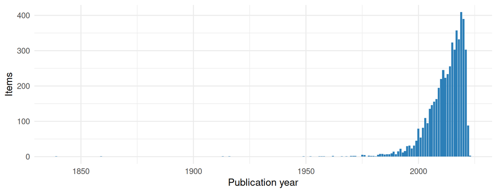

### Types of items

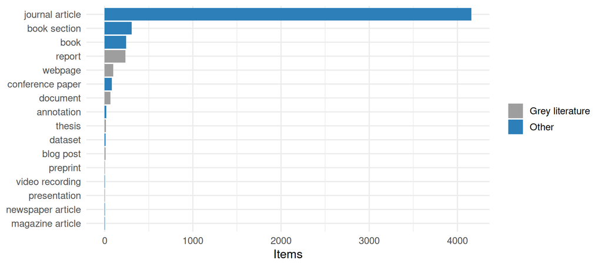

### Open access

Open access status of the publications found in OpenAlex. *Gold* and *diamond*: open in an open access journal; *hybrid*: open in a subscription journal; *green*: an open copy is in a repository; *bronze*: free to read on the publisher’s site; *closed*: not openly available.

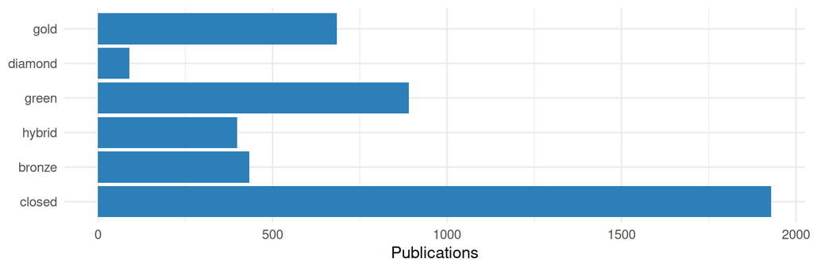

### Most frequent journals

| Journal | Items |
| --- | --- |
| Biological Invasions | 329 |
| NeoBiota | 84 |
| Biological Conservation | 82 |
| Diversity and Distributions | 82 |
| PLoS ONE | 77 |
| Journal of Applied Ecology | 68 |
| Conservation Biology | 59 |
| Frontiers in Ecology and the Environment | 53 |
| Trends in Ecology & Evolution | 51 |
| Ecology Letters | 49 |

### Countries of the authors

Number of publications with at least one author from the country, for the publications found in OpenAlex.

| Country | Publications |
| --- | --- |
| United States | 1479 |
| Australia | 751 |
| United Kingdom | 713 |
| South Africa | 410 |
| Germany | 391 |
| France | 353 |
| Canada | 312 |
| New Zealand | 287 |
| Spain | 258 |
| Italy | 258 |
| Switzerland | 245 |
| Czechia | 206 |
| China | 184 |
| Netherlands | 163 |
| Brazil | 145 |

## How the checks work

**NoteDetails of the checks**

#### identifiers

##### DOI coverage (`met_id_doi`)

Number and share of items with a valid DOI, and items whose DOI field is filled but contains no valid DOI. DOIs are extracted with `openalexPro::extract_doi()` and lower cased.

##### ISBN coverage (`met_id_isbn`)

Number and share of items with an ISBN, overall and for the item types which should have one (`book`, `bookSection`).

##### ISSN coverage (`met_id_issn`)

Number and share of items with an ISSN, overall and for the item types which should have one (`journalArticle`, `magazineArticle`).

##### ISSN not in the standard form (`met_id_issn_form`)

Items whose ISSN field is not in the standard form: each ISSN as `1234-567X` (with hyphen, capital X), several separated by “,”. The ISSNs are checked with their check digit. If all are valid, the standard form is proposed; otherwise the item is listed with the ISSNs which are not valid.

##### DOIs in the wrong field (`met_id_doi_misplaced`)

Items with an empty DOI field but a DOI in the `Url` or `Extra` field. These DOIs are not used for the OpenAlex lookup and should be moved to the DOI field.

##### DOIs in the wrong form (`met_id_doi_form`)

Items whose DOI field contains a valid DOI, but not as a bare DOI: as a link (`https://doi.org/10.…`), with a prefix (`doi:`, `DOI`), URL-encoded (`%5B` for `[`) or with spaces or other characters around it. Citation styles add the link themselves, so a link in the DOI field appears twice in a bibliography. The bare DOI is the one recognised by `openalexPro::extract_doi()`, keeping its upper and lower case.

##### DOIs which do not exist (`met_id_doi_exists`)

Items whose DOI field contains a DOI in the right form which does not exist at doi.org: usually a typo, a shortened DOI, or a DOI with extra characters at the end (`.`, `;`, a link to supplementary material). Only DOIs which are not found in OpenAlex are checked at doi.org. Where the DOI without the extra characters at the end exists, it is given as suggestion.

##### Items without identifier (`met_id_none`)

Items with none of DOI, ISBN, ISSN or Url. These items can neither be checked against OpenAlex nor easily be retrieved by readers.

##### DOIs found in OpenAlex for items without a DOI (`met_id_candidates`)

For items without a DOI, OpenAlex was searched by title, and by the PubMed ID (line `PMID: …` in Extra), and Crossref by ISBN and title (see [get_doi_candidates()]).

#### metadata

##### Filled fields per item type (`met_meta_fields`)

Percentage of items with a filled field, per item type, for the main fields: Title, Author, Publication Year, Publication Title, Publisher, DOI, ISBN, ISSN, Url, Abstract Note and Language. Not every field is expected for every item type, e.g. reports have no Publication Title.

##### Problematic publication years (`met_meta_year`)

Items whose date is missing (`missing`), from whose date Zotero could not derive a year (`unparseable`), or whose year lies in the future (`future`).

##### Duplicate items (`met_meta_duplicates`)

Items which are in the group more than once, identified by the same DOI, or by the same normalised title (lower case, letters and digits only), publication year and first word of the first author.

##### Language not given as a standard code (`met_meta_language`)

Items whose language is not given as a standard language code, i.e. a two-letter ISO 639-1 code, optionally with a region (`en`, `en-US`), but e.g. as a name (`English`), a three-letter code (`eng`) or in a different spelling (`EN`, `en_us`). Citation styles and other tools only recognise the codes. Where the value is recognised, the standard code is proposed, based on the ISO 639-2 list (R package ISOcodes): codes, three-letter codes and the English names of the languages. Other values, e.g. names in the language itself, several languages or other text, are listed without a proposal.

#### openalex_check

##### Zotero DOIs found in OpenAlex (`met_check_found`)

Valid Zotero DOIs which were / were not found in OpenAlex. A DOI which is not found is either not indexed by OpenAlex or wrong (see `met_id_doi_exists` for DOIs which do not exist). DOIs of works which OpenAlex has under another DOI (e.g. the old and the new DOI of an article) count as found.

##### Retracted works (`met_check_retracted`)

Works flagged as retracted by OpenAlex, with the key of the Zotero item(s) with the same DOI.

##### Wrong DOIs (`met_check_mismatch`)

Items whose DOI points in OpenAlex to a work with a different title or year, which usually means that the wrong DOI is attached to the item. An item is flagged when the title similarity (normalised Levenshtein distance) is below 0.8 or the years differ by more than one. Items with the line `DOI checked: correct` in Extra (someone checked that the DOI is right, e.g. a book chapter with the DOI of the book, or a wrong year in OpenAlex) are not listed.

##### Item type agreement (`met_check_type`)

Zotero item type compared with the OpenAlex work type for items with the same DOI.

##### Missing dates found in OpenAlex (`met_check_date`)

Items without a date whose DOI was found in OpenAlex: the publication date in OpenAlex is proposed. OpenAlex gives 1 January when only the year is known, so such dates are proposed as the year only. Items whose DOI points to a different publication are left out.

##### Empty fields found in OpenAlex (`met_check_fill`)

Journal articles with an empty journal, volume, issue or pages field whose DOI was found in OpenAlex with these details: the values in OpenAlex are proposed. The journal is only taken if the publication is in a journal in OpenAlex (not e.g. a repository). Page ranges which end before they start (e.g. `1260-2`, shortened or wrong) are not proposed. Items whose DOI points to a different publication are left out.

##### Language differs from OpenAlex (`met_check_language`)

Items whose language in Zotero differs from the language of their DOI in OpenAlex. Only the language is compared, not the region (`en-US` and `en` are the same), and only for items whose language is given as a language code (see “Language not given as a language code”). Items without a language are listed under “No language”.

##### OpenAlex ID in the Extra field (`met_check_openalex_id`)

Items whose DOI was found in OpenAlex, compared with the OpenAlex ID noted in their Extra field (a line `OpenAlex: W…`). Items without such a line can get it, which links them to OpenAlex for later checks. Items with a different ID are listed for checking: OpenAlex merges records, and the ID of a merged record redirects to the new one. Items whose DOI points to a different publication are left out.

##### OpenAlex ID in the Extra field not valid (`met_check_extra_id`)

Checks the lines `OpenAlex: …` in the Extra field (looked up by [get_extra_ids()]). A line is not valid if - it is not an OpenAlex work ID (`W` and digits), - the item has several lines with different IDs, - the ID is not in OpenAlex (wrong, or merged into another record), or - the work is a different publication: its DOI is not the DOI of the item, or, for items without DOI, its title is not similar (similarity below 0.8, see [title_similarity()]).

#### profile

##### Publication years (`met_prof_year`)

Number of items per publication year, with cumulative counts. Items without a year are counted as `NA`.

##### Open access status (`met_prof_oa`)

OpenAlex open access status (gold, diamond, green, hybrid, bronze, closed) of the works, overall and per publication year.

##### Top journals (`met_prof_journals`)

The 50 most frequent journals, from the Publication Title in Zotero and the source of the primary location in OpenAlex. Ties at rank 50 are included.

##### Author countries (`met_prof_countries`)

Number of works with at least one author affiliated with an institution in a country, per country (ISO 3166-1 alpha-2 codes from OpenAlex).

##### Item types and grey literature (`met_prof_types`)

Number of items per item type (Zotero) or work type (OpenAlex), and the share of grey literature, i.e. reports, theses, dissertations, web pages, documents, presentations, manuscripts, blog posts and preprints.

##### Languages (`met_prof_language`)

Languages as entered, and normalised to two letter codes (lower case, region removed, English spellings mapped to `en`). Inconsistent codes in the language as entered are a quality issue in themselves.

#### maintenance

##### Group activity (`met_maint_activity`)

Items added per month, and items added / modified in the 30 days before the metrics were calculated.

##### Items without tags (`met_maint_tags`)

Items without manual tags. Automatic tags, e.g. keywords imported from the publisher, are ignored.

IPBES Literature Report 0.7.0 · [source code on GitHub](https://github.com/IPBES-Data/IPBES.LiteratureReport) (© IPBES.LiteratureReport authors, [MIT licence](https://opensource.org/license/mit)) · reports and data on this website: [CC0 1.0](https://creativecommons.org/publicdomain/zero/1.0/) (no rights reserved)